# Assignment 4 - Task 2

Evie Vermeer

11/4/2021

### Introduction:

This study is exploring data of snowshoe hares, a keystone species sampled in the Bonanza Creek Experimental Forest starting in 1999. Snowshoe hares experience population fluctuations of 8-11 years. These data were published in 2017.

The report below will explore annual hare counts in the study, as well as relationships between hare weight and sex, as well as hindfoot length and sex. The report will visualize data in addition to running statistical analyses with interpretation.

### Data and Analyses:

Appreciation for the data in this study goes to: Kielland, K., F.S. Chapin, R.W. Ruess, and Bonanza Creek LTER. 2017. Snowshoe hare physical data in Bonanza Creek Experimental Forest: 1999-Present ver 22. Environmental Data Initiative. https://doi.org/10.6073/pasta/03dce4856d79b91557d8e6ce2cbcdc14 (Accessed 2021-11-04).

### Part i) Visualizing annual juvenile snowshoe hare trap counts:

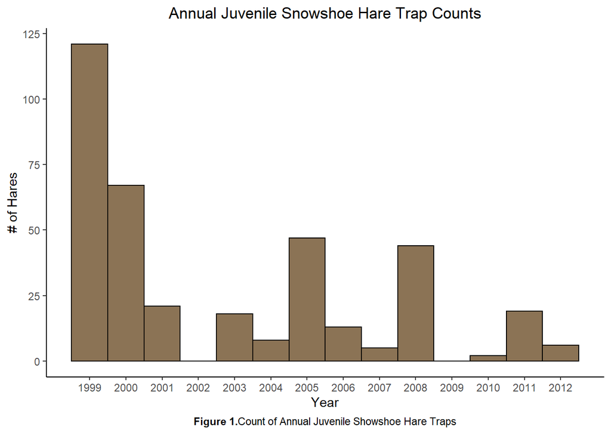

The histogram above shows several key takeaways. First, the maximum trapped count of 121 in 1999 stands in stark contrast to the zero counts in both 2002 and 2009. Also, the mean count of juvenile showshoe hares per year was 30.92, while the median was just 18.5 and the standard deviation was 34.68. Lastly, the issue of study effort here could very well skew our data. In order to ensure more standardized analyses in the future, establishing a consistent amount of study days and traps each year would help with more accurate analysis. This would also assist in analyzing whether or not this population decline is part of a typical 8-11 year population cycle that the study mentions, or if other factors may be at play.

### Part ii) Visualizing juvenile snowshoe hare weights by sex and site:

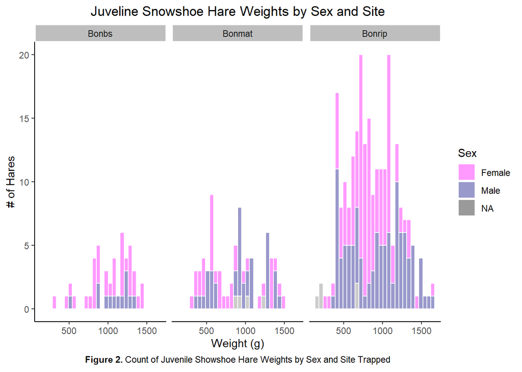

The faceted visualization here shows a distribution of juvenile snowshoe hare weights by each site at which they were trapped. The data here show that the Bonrip site collected far more observations than the two others. It also does not reveal any first indications of clear comparison between male and female snowshoe hare weights. This will be investigated further in the table below.

Table 1. Average Weights of Juvenile Snowshoe Hares by Site and Sex

| Site | Sex | Median Weight(g) | Average Weight (g) | Standard Deviation (g) | Sample Size (n) |
| --- | --- | --- | --- | --- | --- |
| Bonbs | Female | 1060 | 1022.1 | 293.0 | 34 |
| Bonbs | Male | 1150 | 1073.1 | 222.6 | 13 |
| Bonmat | Female | 670 | 802.1 | 364.5 | 35 |
| Bonmat | Male | 940 | 938.0 | 318.4 | 38 |
| Bonmat | NA | 965 | 997.5 | 158.2 | 4 |
| Bonrip | Female | 800 | 824.9 | 255.9 | 126 |
| Bonrip | Male | 990 | 928.7 | 350.7 | 109 |
| Bonrip | NA | 200 | 372.0 | 258.8 | 5 |

These data show numeric representation of the histograms above. We see generally that the male hares weigh more than the female hares, but sample sizes are mostly small, and more analysis to clarify these observations is needed.

### Part iii) Comparing male and female juvenile snowshoe hare weights:

Table 2. Average Weights of Juvenile Snowshoe Hares by Sex

| Sex | Median Weight (g) | Average Weight (g) | Standard Deviation (g) | Sample Size (n) |
| --- | --- | --- | --- | --- |
| Female | 825 | 855.2 | 293.4 | 198 |
| Male | 990 | 942.7 | 335.3 | 160 |
| NA | 660 | 650.0 | 389.3 | 13 |

### Part iv) Relationship between juvenile snowshoe hare weight and hind foot length:

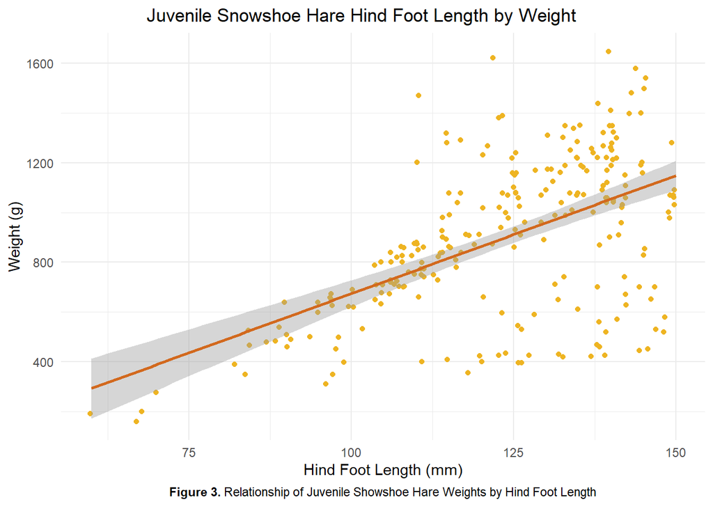

### Summary of report findings:

The report above has a few main findings:

Citation: Kielland, K., F.S. Chapin, R.W. Ruess, and Bonanza Creek LTER. 2017. Snowshoe hare physical data in Bonanza Creek Experimental Forest: 1999-Present ver 22. Environmental Data Initiative. https://doi.org/10.6073/pasta/03dce4856d79b91557d8e6ce2cbcdc14 (Accessed 2021-11-07).